# Exploratory Data Analysis

```r
library(tidyverse)
library(jsonlite)
report_theme <- ggplot2::theme_bw() +
  ggplot2::theme(panel.border = ggplot2::element_rect(color = "black",
                                                      fill = NA),
                 panel.grid.major = ggplot2::element_line(color = "black",
                                                          linetype = "dotted"),
                 panel.grid.minor = ggplot2::element_line(color = "black",
                                                          linetype = "dotted"))
```

In this notebook I will be doing an exploratory data analysis looking to answer the question:

> What factors correlate with users booking?

Particularly, I’m interesting in looking at what factors correlate with the conversion of leads to bookings. As such, I will primarily work with the leads data set with relevant information from the referral data set and a logical column indicating a booking event.

# Data Import and Preparation

First, I need to import and prepare the data for analysis.

```r
room_key_data <- read_tsv("data.tsv", progress = FALSE) %>%
  rownames_to_column() %>%
  rename(key = rowname) %>%
  mutate(lead_event = !(lead == "null"),
         booking_event = !(booking == "null"))
```

```r
referral_key <- room_key_data %>%
  filter(referral != "null") %>%
  select(key, lead_event, booking_event)
referral <- room_key_data %>%
  filter(referral != "null") %>%
  .$referral %>%
  map_df(fromJSON) %>%
  bind_cols(referral_key) %>%
  select(key, everything()) %>%
  rename(visitor_id = `visitor-id`,
         event_id_referral = `event-id`,
         ts_referral = ts,
         location_tid = `location-tid`,
         partner_code = `partner-code`,
         check_in = `check-in`,
         check_out = `check-out`)
```

```r
lead_key <- room_key_data %>%
  filter(lead != "null") %>%
  select(key, booking_event)
lead <- room_key_data %>%
  filter(lead != "null") %>%
  .$lead %>%
  map_df(fromJSON) %>%
  bind_cols(lead_key) %>%
  select(key, everything()) %>%
  rename(visitor_id = `visitor-id`,
         event_id_lead = `event-id`,
         ts_lead = ts,
         rate_partner = `rate-partner`)
```

```r
booking_key <- room_key_data %>%
  filter(booking != "null") %>%
  select(key)

booking <- room_key_data %>%
  filter(booking != "null") %>%
  .$booking %>%
  map_df(fromJSON) %>%
  bind_cols(booking_key) %>%
  select(key, everything())
```

## Preparation

Here I want to combine some information from the referral data set into the lead data set. As part of this, I also rename a few columns and convert some of the columns to different data types. Specifically the ts columns are converted to datetime and the check_in and check_out columns are converted to dates.

```r
referral_info <- referral %>%
  filter(lead_event == TRUE) %>%
  select(-event_id_referral, -type, -lead_event, -booking_event)
lead_ref <- lead %>%
  select(-event_id_lead, - type) %>%
  left_join(referral_info, by = c("key", "visitor_id")) %>%
  rename(rate_partner_lead = rate_partner,
         partner_code_referral = partner_code) %>%
  mutate(ts_lead = lubridate::as_datetime(ts_lead / 1000),
         ts_referral = lubridate::as_datetime(ts_referral / 1000),
         check_in = lubridate::ymd(check_in),
         check_out = lubridate::ymd(check_out))
```

```r
lead_ref
```

| key | visitor_id | ts_lead | rate_partner_lead | booking_event | ts_referral | location_tid | partner_code_referral | check_in | check_out | udicode |
| --- | --- | --- | --- | --- | --- | --- | --- | --- | --- | --- |
| 50 | 59e2dd7c-e7d1-4995-ad48-623f085e008b | 2017-10-15 04:02:01 | IHG | FALSE | 2017-10-15 04:01:00 | qsS5DhT5ALRWcdWlb7QAMxD | IHG |  |  | 2nT8ISG4U04s7Cc05g9krVMw |
| 97 | 59e2ddb2-f87b-4d0e-8e0a-521339d8eb1f | 2017-10-15 04:18:54 | MRT | FALSE | 2017-10-15 04:01:54 | Edj3ClskapQIH3knEkOqRaX | MRT | 2017-10-19 | 2017-10-21 | 2imKoaG4Y04sA5005g9krVMw |
| 125 | 59e2ddc6-db34-498f-97b3-8fe92a863f92 | 2017-10-15 04:13:29 | MRT | FALSE | 2017-10-15 04:02:14 | 0lklMfitQVPJQaqOgwqHHRy | MRT | 2018-08-30 | 2018-09-03 | 1wSZbEG4V04s7jz05g9krVMw |
| 130 | 59e2ddc3-677b-4d46-b6c4-8c2cec58e9b4 | 2017-10-15 04:14:11 | TCLK | FALSE | 2017-10-15 04:02:17 | 1ZmMvwG4T04s5cO05g9krVMw | HLTN | 2017-11-09 | 2017-11-11 | 1Zf3rcG4T04s6Rb05g9krVMw |
| 210 | 59e29915-613c-425e-89db-d5201e250e35 | 2017-10-15 04:04:53 | CHC | FALSE | 2017-10-15 04:03:32 | 4Bl9bUG4U04s5cO05g9krVMw | IHG |  |  | 4BdzO4G4U04s7OE05g9krVMw |
| 222 | 59e2de1c-daf7-48e2-85d7-5f9566270b3e | 2017-10-15 04:25:46 | WYND | FALSE | 2017-10-15 04:03:40 | 2dgRdYG4S04s5cO05g9krVMw | IHG |  |  | 80dc046165f4429f9510a96b |
| 263 | 584cd46b-9391-4f06-bde4-347eab8e708b | 2017-10-15 04:28:36 | IHG | TRUE | 2017-10-15 04:04:14 | 00eq5gG4X04s5cO05g9krVMw | IHG |  |  | 00WxGaG4X04s8oS05g9krVMw |
| 283 | 59e2ddfc-eafb-48a5-a6eb-03e84238aacb | 2017-10-15 17:19:07 | HLTN | FALSE | 2017-10-15 04:04:34 | 0S5S6aG4S04s5cO05g9krVMw | MRT | 2017-10-21 | 2017-10-22 | 878a446955d04f9fb4120bd3 |
| 286 | 59e2de56-0c86-4270-b0d5-2d12854111f9 | 2017-10-15 04:05:03 | IHG | FALSE | 2017-10-15 04:04:38 | qsS5DhT5ALRWcdWlb7QAMxD | IHG |  |  | 4PH2emG4U04s7Q205g9krVMw |
| 313 | 59e2dd87-2986-42be-a04a-34352ed7e5f9 | 2017-10-15 04:27:02 | STRWD | FALSE | 2017-10-15 04:05:08 | 4M2SrAG4S04s5cO05g9krVMw | HLTN | 2018-01-27 | 2018-01-28 | 4Lv4QyG4S04s6DM05g9krVMw |

[output cut: 990 more lines]

# Analysis

The following are some initial questions looking at how some of the variables interact.

## Time Difference

I want to look at whether or not the time difference between lead and referral corresponds with a booking.

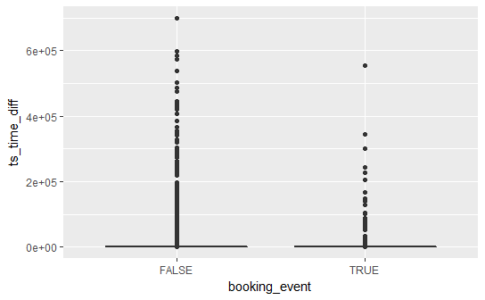

```r
lead_ref %>%
  mutate(ts_time_diff = as.numeric(ts_lead - ts_referral)) %>%
  # filter(ts_time_diff < 3000) %>%
  ggplot(aes(x = booking_event, y = ts_time_diff)) +
  geom_boxplot()
```

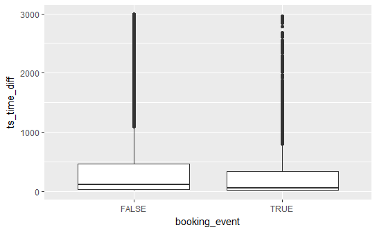

```r
lead_ref %>%
  mutate(ts_time_diff = as.numeric(ts_lead - ts_referral)) %>%
  filter(ts_time_diff < 3000) %>%
  ggplot(aes(x = booking_event, y = ts_time_diff)) +
  geom_boxplot()
```

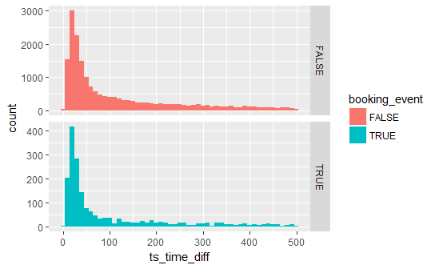

```r
lead_ref %>%
  mutate(ts_time_diff = as.numeric(ts_lead - ts_referral)) %>%
  filter(ts_time_diff < 500) %>%
  ggplot(aes(x = ts_time_diff, fill = booking_event)) +
  geom_histogram(binwidth = 10) +
  facet_grid(booking_event ~ ., scales = "free_y")
```

There does not appear to be a large difference between the times at which booking events occur or don’t occur. There is possibly a greater concentation of booking events at short times (time difference < 100 s), but both display a similar tail at large time differences.

## Check-in Time Difference

Here I want to look at the time difference between the proposed check-in date and both the referral and lead time stamp date.

First, I want to look at the presence of any NAs in the date differences.

```r
lead_ref %>%
  mutate(ts_time_diff = as.numeric(check_in - lubridate::as_date(ts_referral))) %>%
  group_by(booking_event) %>%
  summarize(check_in_NA = sum(is.na(check_in)),
            ts_referral_NA = sum(is.na(ts_referral)),
            time_diff_NA = sum(is.na(ts_time_diff)))
```

| booking_event | check_in_NA | ts_referral_NA | time_diff_NA |
| --- | --- | --- | --- |
| FALSE | 4117 | 95 | 4117 |
| TRUE | 330 | 7 | 330 |

Here I can see that there are a number of NA’s in the check-in data and a few in the timestamp from the referral data. There were no NA’s in the timestamp for the lead data. Since the check-in NA number and the time difference NA number are the same, I can assume that the NA’s from the referral data overlap with those from the check-in data.

For this next analysis, I will remove all of the NA’s as they cannot contribute.

### Check-in - Referral

First, I will look at the difference in time between the check-in date and the referral timestamp.

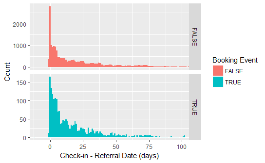

```r
lead_ref %>%
  filter(!is.na(check_in)) %>%
  mutate(ts_time_diff = as.numeric(check_in - lubridate::as_date(ts_referral))) %>%
  ggplot(aes(x = ts_time_diff, fill = booking_event)) +
  geom_histogram(binwidth = 1) +
  facet_grid(booking_event ~ ., scales = "free_y") +
  coord_cartesian(xlim = c(-10, 100)) +
  labs(x = "Check-in - Referral Date (days)",
       y = "Count",
       fill = "Booking Event")
```

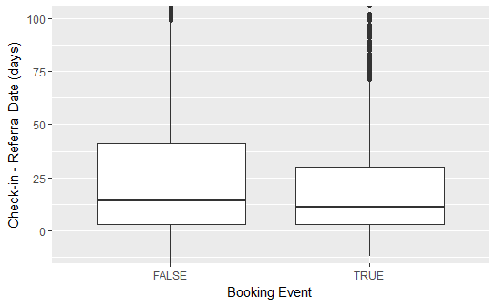

```r
lead_ref %>%
  filter(!is.na(check_in)) %>%
  mutate(ts_time_diff = as.numeric(check_in - lubridate::as_date(ts_referral))) %>%
  ggplot(aes(x = booking_event, y = ts_time_diff)) +
  geom_boxplot() +
  coord_cartesian(ylim = c(-10, 100)) +
  labs(y = "Check-in - Referral Date (days)",
       x = "Booking Event")
```

### Check-in - Lead

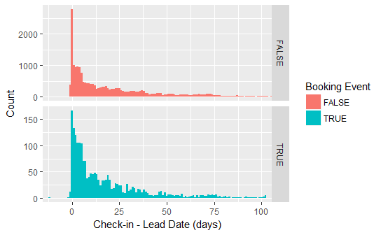

```r
lead_ref %>%
  filter(!is.na(check_in)) %>%
  mutate(ts_time_diff = as.numeric(check_in - lubridate::as_date(ts_lead))) %>%
  ggplot(aes(x = ts_time_diff, fill = booking_event)) +
  geom_histogram(binwidth = 1) +
  facet_grid(booking_event ~ ., scales = "free_y") +
  coord_cartesian(xlim = c(-10, 100)) +
  labs(x = "Check-in - Lead Date (days)",
       y = "Count",
       fill = "Booking Event")
```

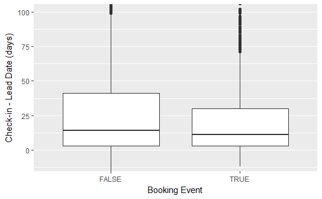

```r
lead_ref %>%
  filter(!is.na(check_in)) %>%
  mutate(ts_time_diff = as.numeric(check_in - lubridate::as_date(ts_lead))) %>%
  ggplot(aes(x = booking_event, y = ts_time_diff)) +
  geom_boxplot() +
  coord_cartesian(ylim = c(-10, 100)) +
  labs(y = "Check-in - Lead Date (days)",
       x = "Booking Event")
```

The check-in lead time difference shows a similar pattern to the check-in referral time difference.

Of note, there are a few interesting data points in this set. There are a small number of points with check-in times earlier than the time stamp for the referral or lead. When combined with a TRUE booking event, this indicates that these bookings were done after the time. Most likely, these are some typos in the check-in date.

```r
lead_ref %>%
  mutate(ts_time_diff = as.numeric(check_in - lubridate::as_date(ts_lead))) %>%
  filter(booking_event == TRUE) %>%
  filter(ts_time_diff < 0)
```

| key | visitor_id | ts_lead | rate_partner_lead | booking_event | ts_referral | location_tid | partner_code_referral | check_in | check_out | udicode | ts_time_diff |
| --- | --- | --- | --- | --- | --- | --- | --- | --- | --- | --- | --- |
| 565 | 59e2df57-4e5d-4356-8864-72830158e96b | 2017-10-15 04:09:08 | MRT | TRUE | 2017-10-15 04:08:55 | 1ORYhsG4T04s5cO05g9krVMw | MRT | 2017-10-14 | 2017-10-15 | 2F9Bi4G4V04s7mm05g9krVMw | -1 |
| 16210 | 59e33f3d-b4cc-4f50-b1f2-82049a321f83 | 2017-10-15 11:01:05 | IHG | TRUE | 2017-10-15 10:58:05 | 37UqYKG4T04s5cO05g9krVMw | IHG | 2017-04-12 | 2017-05-12 | NA | -186 |
| 127863 | 59c9c429-ff06-470f-806a-39e31151682d | 2017-10-16 18:58:07 | IHG | TRUE | 2017-10-16 00:39:47 | 2QMPdwG4S04s5cO05g9krVMw | IHG | 2017-10-15 | 2017-10-16 | NA | -1 |
| 135941 | 5828ff38-b4b7-4e2a-97fb-a9ec188c8331 | 2017-10-16 01:23:09 | HLTN | TRUE | 2017-10-16 01:22:35 | 0Y9NPkG4T04s5cO05g9krVMw | CHC | 2017-10-15 | 2017-10-16 | NA | -1 |
| 264429 | 59e4df69-08a9-4579-89d5-eb9b063c51ec | 2017-10-18 04:35:50 | HLTN | TRUE | 2017-10-16 16:33:45 | 2kcNYuG4S04s5cO05g9krVMw | HLTN | 2017-10-16 | 2017-10-17 | 2kT0m8G4S04s61Y05g9krVMw | -2 |
| 398992 | 59e5501e-49d3-40ba-ae73-6d934a62c6ff | 2017-10-17 00:34:58 | HLTN | TRUE | 2017-10-17 00:34:38 | 08TUYqG4T04s5cO05g9krVMw | HLTN | 2017-10-16 | 2017-10-17 | 08M6PAG4T04s6Gr05g9krVMw | -1 |
| 419018 | 59e56746-4ebc-4853-9181-a47eb206c632 | 2017-10-17 02:13:33 | MRT | TRUE | 2017-10-17 02:13:26 | GSlUJB8j5c3J2EcgCNMumK6 | MRT | 2017-10-16 | 2017-10-17 | 1V0yw4GtW04s1QN05g9krVMw | -1 |
| 439678 | 59e59170-2d82-4963-8852-2ca203364677 | 2017-10-17 05:13:28 | IHG | TRUE | 2017-10-17 05:13:20 | 0zuhfsG4T04s5cO05g9krVMw | IHG | 2017-10-16 | 2017-10-17 | d55542acdaf042f0be89201f | -1 |
| 441297 | 59e55c66-5e31-4009-9e25-0f12f00d349b | 2017-10-17 05:41:55 | HLTN | TRUE | 2017-10-17 05:40:56 | 1JFPIOG4T04s5cO05g9krVMw | HLTN | 2017-10-16 | 2017-10-19 | NA | -1 |
| 517774 | 59e623cd-524a-4088-97bd-da1db687043b | 2017-10-17 15:38:14 | IHG | TRUE | 2017-10-17 15:37:50 | 4WfL1MG4U04s5cO05g9krVMw | IHG | 2017-03-10 | 2017-03-11 | 4WY4gqG4U04s7R205g9krVMw | -221 |

[output cut: 9 more lines]

## Partner

For this section, I want to look at whether the specific partner corresponds with an increased booking rate. In this section I will look at the rate partner that the lead goes to, the referral partner that the user came from, and whether those partners are the same from referral to lead.

### Rate Partner Lead Data

The lead rate partners are shown using a bar plot with the existence of a booking event given by the colors. The first bar plot gives a simple count of the number of TRUE and FALSE booking events for each partner. The second plot gives the proportion of booking events for each partner.

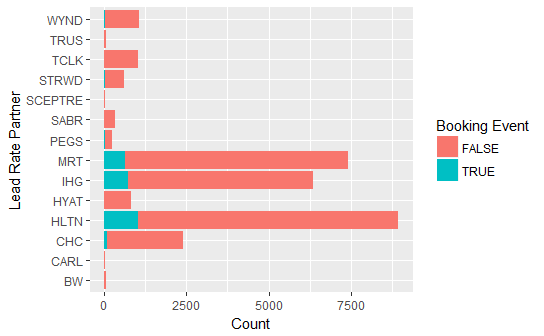

```r
lead_ref %>%
  ggplot(aes(x = rate_partner_lead, fill = booking_event)) +
  geom_bar() +
  coord_flip() +
  labs(y = "Count",
       x = "Lead Rate Partner",
       fill = "Booking Event")
```

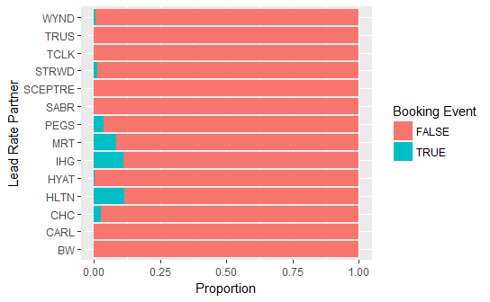

```r
lead_ref %>%
  ggplot(aes(x = rate_partner_lead, fill = booking_event)) +
  geom_bar(position = "fill") +
  coord_flip() +
  labs(y = "Proportion",
       x = "Lead Rate Partner",
       fill = "Booking Event")
```

The proportion bar plot shows that the partners PEGS, MRT, IHG, HLTN, and CHC have the highest proportion of booking events. MRT, IGH< HLTN, and CHC are also the partners with the largest number of leads which may influence their higher rate of booking.

### Referral Partner Data

The referral partner data is given in two bar plots as with the lead data. The first bar plot is acount of the number of TRUE or FALSE booking events for each referral partner. The second bar plot is the propotion of TRUE and FALSE booking events for each referral partner.

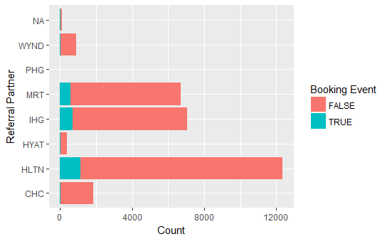

```r
lead_ref %>%
  ggplot(aes(x = partner_code_referral, fill = booking_event)) +
  geom_bar() +
  coord_flip() +
  labs(y = "Count",
       x = "Referral Partner",
       fill = "Booking Event")
```

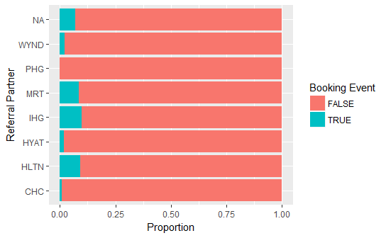

```r
lead_ref %>%
  ggplot(aes(x = partner_code_referral, fill = booking_event)) +
  geom_bar(position = "fill") +
  coord_flip() +
  labs(y = "Proportion",
       x = "Referral Partner",
       fill = "Booking Event")
```

Here, the proportion data shows that MRT, IHG, and HLTN are the three biggest sources of booking events. However, more of the referral partners have noticeable booking event proportions.

### Same Partner Data

For the same partner data I am interested in calculating which users followed a lead from the same partner that referred them to Room Key. For this data, I noticed that there are a few referral partners that show up as NA. Since these are only a small number of the total leads and bookings, I will filter these out.

```r
lead_ref %>%
  summarize(sum(is.na(partner_code_referral)))
```

| sum(is.na(partner_code_referral)) |
| --- |
| 102 |

As with the previous partner sections, I will plot this data in two ways. First a simple count of TRUE or FALSE booking events for partners that are the same from referral to lead and for ones that are different. Second a bar plot of the proportions of booking events.

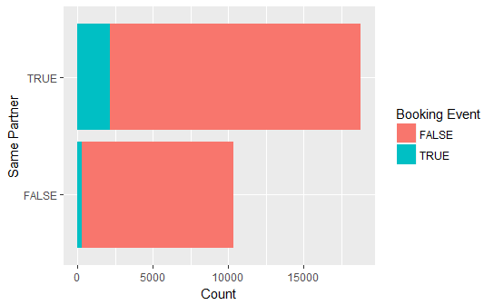

```r
lead_ref %>%
  mutate(same_partner = (partner_code_referral == rate_partner_lead)) %>%
  filter(!is.na(same_partner)) %>%
  ggplot(aes(x = same_partner, fill = booking_event)) +
  geom_bar() +
  coord_flip() +
  labs(y = "Count",
       x = "Same Partner",
       fill = "Booking Event")
```

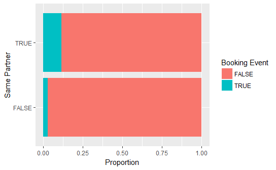

```r
lead_ref %>%
  mutate(same_partner = (partner_code_referral == rate_partner_lead)) %>%
  filter(!is.na(same_partner)) %>%
  ggplot(aes(x = same_partner, fill = booking_event)) +
  geom_bar(position = "fill") +
  coord_flip() +
  labs(y = "Proportion",
       x = "Same Partner",
       fill = "Booking Event")
```

Interestingly, the vast majority of booking events occurs when the partners are the same from referral to lead. This is true, even though close to 36% of the leads occur when the partners are not the same. Given that, only 12% of the bookings occur when partners are not the same.

```r
lead_ref %>%
  mutate(same_partner = (partner_code_referral == rate_partner_lead)) %>%
  filter(!is.na(same_partner)) %>%
  group_by(booking_event) %>%
  summarize(prop_same = mean(same_partner), prop_diff = 1 - prop_same)
```

| booking_event | prop_same | prop_diff |
| --- | --- | --- |
| FALSE | 0.6229999 | 0.3770001 |
| TRUE | 0.8834432 | 0.1165568 |

```r
lead_ref %>%
  mutate(same_partner = (partner_code_referral == rate_partner_lead)) %>%
  filter(!is.na(same_partner)) %>%
  # group_by(booking_event) %>%
  summarize(prop_same = mean(same_partner),
            prop_diff = 1 - prop_same)
```

| prop_same | prop_diff |
| --- | --- |
| 0.6446737 | 0.3553263 |

## Location-tid and udicode

To get a sense of how location-tid and udicode may correlate with the booking rate, I start by doing some calculations on these variables. After grouping by the variable, I then calculate the total number of appearences of that variable, the total number of true and false events for that variable, and the proportion of the true and false events to the total occurrences of that variable. I can then see the occurrences of the variable with the most true events and the highest proportion of true events.

```r
lead_ref %>%
  group_by(location_tid) %>%
  summarize(total = n(),
            total_true = sum(booking_event),
            total_false = total - total_true,
            prop_true = total_true / total,
            prop_false = total_false / total) %>%
  arrange(desc(total_true), desc(total), desc(prop_true)) %>%
  select(location_tid, total_true, total, prop_true, everything())
```

| location_tid | total_true | total | prop_true | total_false | prop_false |
| --- | --- | --- | --- | --- | --- |
| 1z6pfcG4S04s5cO05g9krVMw | 34 | 763 | 0.04456094 | 729 | 0.9554391 |
| 0gyue0G4S04s5cO05g9krVMw | 29 | 324 | 0.08950617 | 295 | 0.9104938 |
| 3nEdZgG4S04s5cO05g9krVMw | 25 | 255 | 0.09803922 | 230 | 0.9019608 |
| 19eTM8G4S04s5cO05g9krVMw | 22 | 348 | 0.06321839 | 326 | 0.9367816 |
| 3ov3BFuzn8KEW7WeLgW3Ebg | 21 | 214 | 0.09813084 | 193 | 0.9018692 |
| 1TCqauG4S04s5cO05g9krVMw | 19 | 227 | 0.08370044 | 208 | 0.9162996 |
| Edj3ClskapQIH3knEkOqRaX | 18 | 286 | 0.06293706 | 268 | 0.9370629 |
| 13N6oaG4T04s5cO05g9krVMw | 16 | 181 | 0.08839779 | 165 | 0.9116022 |
| 0a1eo2udv4HvJ3sS1bWxEiD | 15 | 169 | 0.08875740 | 154 | 0.9112426 |
| 0vWrPkG4S04s5cO05g9krVMw | 15 | 94 | 0.15957447 | 79 | 0.8404255 |

[output cut: 990 more lines]

Note that the location_tid does have a few NA entries (131), but they are relatively small. There are a number of locations with a large number of true booking events that are 5% or more true in proportion to the total number of occurrences of that particular location.

```r
lead_ref %>%
  group_by(udicode) %>%
  summarize(total = n(),
            total_true = sum(booking_event),
            total_false = total - total_true,
            prop_true = total_true / total,
            prop_false = total_false / total) %>%
  # filter(total_true > 1) %>%
  arrange(desc(total_true), desc(total), desc(prop_true)) %>%
  select(udicode, total_true, total, prop_true, everything())
```

| udicode | total_true | total | prop_true | total_false | prop_false |
| --- | --- | --- | --- | --- | --- |
| NA | 744 | 10531 | 0.07064856 | 9787 | 0.9293514 |
| 1cad0bc5dd0a4645a7a187af | 4 | 29 | 0.13793103 | 25 | 0.8620690 |
| 09pMVEG4T04s6H205g9krVMw | 4 | 23 | 0.17391304 | 19 | 0.8260870 |
| 4ZGdw8G4S04s6Es05g9krVMw | 3 | 26 | 0.11538462 | 23 | 0.8846154 |
| 0grQdEG4S04s5mQ05g9krVMw | 3 | 13 | 0.23076923 | 10 | 0.7692308 |
| 2WkNjkG4T04s6YS05g9krVMw | 3 | 13 | 0.23076923 | 10 | 0.7692308 |
| 2sU01oG4S04s62U05g9krVMw | 3 | 12 | 0.25000000 | 9 | 0.7500000 |
| 3qE6MqG4S04s69U05g9krVMw | 3 | 12 | 0.25000000 | 9 | 0.7500000 |
| 1M5qmOG4S04s5rS05g9krVMw | 3 | 11 | 0.27272727 | 8 | 0.7272727 |
| 01c66d77b17a4f03bec64fa9 | 3 | 8 | 0.37500000 | 5 | 0.6250000 |

[output cut: 990 more lines]

The udicode is a little less clear. The largest number of true booking events occurs for when the udicode is NA. This also encompasses a large number (approximately 1/3) of the total observations.

# Variable Correlation

To determine whether any of the variables correlate with a booking event I will use a chi-square test for the categorical variables and the Pearson product moment correlation coefficient for the numerical variables.

The following new data frame has been created to include all of the new calculated variables and remove the unwanted variables. These new variables include the differences between the timestamps and check-in dates. The check-in and check-out dates are also converted to a time difference with 0 being set to the beginning of the recording period.

```r
lead_ref_new_var <- lead_ref %>%
  mutate(ts_time_diff = as.numeric(ts_lead - ts_referral)) %>%
  mutate(referral_check_in_diff = as.numeric(check_in - lubridate::as_date(ts_referral))) %>%
  mutate(lead_check_in_diff = as.numeric(check_in - lubridate::as_date(ts_lead))) %>%
  mutate(same_partner = (partner_code_referral == rate_partner_lead)) %>%
  mutate(check_in = as.numeric(check_in - lubridate::ymd("2017-10-15"))) %>%
  mutate(check_out = as.numeric(check_out - lubridate::ymd("2017-10-15"))) %>%
  select(-key, -visitor_id) %>%
  select(booking_event, everything())
```

```r
lead_ref_new_var
```

| booking_event | ts_lead | rate_partner_lead | ts_referral | location_tid | partner_code_referral | check_in | check_out | udicode | ts_time_diff | referral_check_in_diff | lead_check_in_diff | same_partner |
| --- | --- | --- | --- | --- | --- | --- | --- | --- | --- | --- | --- | --- |
| FALSE | 2017-10-15 04:02:01 | IHG | 2017-10-15 04:01:00 | qsS5DhT5ALRWcdWlb7QAMxD | IHG |  |  | 2nT8ISG4U04s7Cc05g9krVMw | 60.173 | NA | NA | TRUE |
| FALSE | 2017-10-15 04:18:54 | MRT | 2017-10-15 04:01:54 | Edj3ClskapQIH3knEkOqRaX | MRT | 2017-10-19 | 2017-10-21 | 2imKoaG4Y04sA5005g9krVMw | 1020.088 | 4 | 4 | TRUE |
| FALSE | 2017-10-15 04:13:29 | MRT | 2017-10-15 04:02:14 | 0lklMfitQVPJQaqOgwqHHRy | MRT | 2018-08-30 | 2018-09-03 | 1wSZbEG4V04s7jz05g9krVMw | 674.912 | 319 | 319 | TRUE |
| FALSE | 2017-10-15 04:14:11 | TCLK | 2017-10-15 04:02:17 | 1ZmMvwG4T04s5cO05g9krVMw | HLTN | 2017-11-09 | 2017-11-11 | 1Zf3rcG4T04s6Rb05g9krVMw | 714.480 | 25 | 25 | FALSE |
| FALSE | 2017-10-15 04:04:53 | CHC | 2017-10-15 04:03:32 | 4Bl9bUG4U04s5cO05g9krVMw | IHG |  |  | 4BdzO4G4U04s7OE05g9krVMw | 80.250 | NA | NA | FALSE |
| FALSE | 2017-10-15 04:25:46 | WYND | 2017-10-15 04:03:40 | 2dgRdYG4S04s5cO05g9krVMw | IHG |  |  | 80dc046165f4429f9510a96b | 1325.282 | NA | NA | FALSE |
| TRUE | 2017-10-15 04:28:36 | IHG | 2017-10-15 04:04:14 | 00eq5gG4X04s5cO05g9krVMw | IHG |  |  | 00WxGaG4X04s8oS05g9krVMw | 1461.996 | NA | NA | TRUE |
| FALSE | 2017-10-15 17:19:07 | HLTN | 2017-10-15 04:04:34 | 0S5S6aG4S04s5cO05g9krVMw | MRT | 2017-10-21 | 2017-10-22 | 878a446955d04f9fb4120bd3 | 47673.037 | 6 | 6 | FALSE |
| FALSE | 2017-10-15 04:05:03 | IHG | 2017-10-15 04:04:38 | qsS5DhT5ALRWcdWlb7QAMxD | IHG |  |  | 4PH2emG4U04s7Q205g9krVMw | 25.215 | NA | NA | TRUE |
| FALSE | 2017-10-15 04:27:02 | STRWD | 2017-10-15 04:05:08 | 4M2SrAG4S04s5cO05g9krVMw | HLTN | 2018-01-27 | 2018-01-28 | 4Lv4QyG4S04s6DM05g9krVMw | 1314.088 | 104 | 104 | FALSE |

[output cut: 990 more lines]

## Numeric Variables

In general, all of the numeric varibles show a very small negative correlation with booking events. This seems pretty reasonable as the histograms of the timing showed that the majority of all bookings (and of all events) occur at shorter times with fewer bookings happening at larger times. However, the correlations are incredibly small. The calculations are included below.

### `ts_lead`

```r
cor.test(~ as.numeric(ts_lead) + as.numeric(booking_event),
         data = lead_ref_new_var)
```

```
    Pearson's product-moment correlation

data:  as.numeric(ts_lead) and as.numeric(booking_event)
t = -9.4279, df = 29276, p-value < 2.2e-16
alternative hypothesis: true correlation is not equal to 0
95 percent confidence interval:
 -0.06643039 -0.04359049
sample estimates:
        cor
-0.05501763
```

### `ts_referral`

```r
cor.test(~ as.numeric(ts_referral) + as.numeric(booking_event),
         data = lead_ref_new_var)
```

```
    Pearson's product-moment correlation

data:  as.numeric(ts_referral) and as.numeric(booking_event)
t = -9.2945, df = 29174, p-value < 2.2e-16
alternative hypothesis: true correlation is not equal to 0
95 percent confidence interval:
 -0.06576916 -0.04288765
sample estimates:
        cor
-0.05433554
```

### `ts_time_diff`

```r
cor.test(~ ts_time_diff + as.numeric(booking_event),
         data = lead_ref_new_var)
```

```
    Pearson's product-moment correlation

data:  ts_time_diff and as.numeric(booking_event)
t = -1.2355, df = 29174, p-value = 0.2166
alternative hypothesis: true correlation is not equal to 0
95 percent confidence interval:
 -0.018706416  0.004241632
sample estimates:
         cor
-0.007233344
```

### `lead_check_in_diff`

```r
cor.test(~ lead_check_in_diff + as.numeric(booking_event),
         data = lead_ref_new_var)
```

```
    Pearson's product-moment correlation

data:  lead_check_in_diff and as.numeric(booking_event)
t = -6.558, df = 24829, p-value = 5.561e-11
alternative hypothesis: true correlation is not equal to 0
95 percent confidence interval:
 -0.05399311 -0.02915988
sample estimates:
        cor
-0.04158292
```

### `referral_check_in_diff`

```r
cor.test(~ referral_check_in_diff + as.numeric(booking_event),
         data = lead_ref_new_var)
```

```
    Pearson's product-moment correlation

data:  referral_check_in_diff and as.numeric(booking_event)
t = -6.5636, df = 24829, p-value = 5.356e-11
alternative hypothesis: true correlation is not equal to 0
95 percent confidence interval:
 -0.05402856 -0.02919539
sample estimates:
       cor
-0.0416184
```

### `check_in`

```r
cor.test(~ check_in + as.numeric(booking_event),
         data = lead_ref_new_var)
```

```
    Pearson's product-moment correlation

data:  check_in and as.numeric(booking_event)
t = -6.7874, df = 24829, p-value = 1.167e-11
alternative hypothesis: true correlation is not equal to 0
95 percent confidence interval:
 -0.05544367 -0.03061349
sample estimates:
        cor
-0.04303523
```

### `check_out`

```r
cor.test(~ check_out + as.numeric(booking_event),
         data = lead_ref_new_var)
```

```
    Pearson's product-moment correlation

data:  check_out and as.numeric(booking_event)
t = -7.1298, df = 24829, p-value = 1.033e-12
alternative hypothesis: true correlation is not equal to 0
95 percent confidence interval:
 -0.05760711 -0.03278168
sample estimates:
        cor
-0.04520137
```

## Categorical Variables

All of the chi-squared tests for the categorical variables gave p-values of less than 2.2e-12. This indicates that there is a significant level of dependence between booking events and the categorical variables. One note with these is that the low counts for some of the variable permutations throws an error with the chi-squared approximation used.

### `partner_code_referral`

```r
lead_ref_new_var %>%
  # filter(!is.na(partner_code_referral)) %>%
  select(booking_event, partner_code_referral) %>%
  table() %>%
  chisq.test()
```

```
Chi-squared approximation may be incorrect
```

```
    Pearson's Chi-squared test

data:  .
X-squared = 233.44, df = 6, p-value < 2.2e-16
```

### `rate_partner_lead`

```r
lead_ref_new_var %>%
  select(booking_event, rate_partner_lead) %>%
  table() %>%
  chisq.test()
```

```
Chi-squared approximation may be incorrect
```

```
    Pearson's Chi-squared test

data:  .
X-squared = 607.25, df = 13, p-value < 2.2e-16
```

### `same_partner`

```r
lead_ref_new_var %>%
  select(booking_event, same_partner) %>%
  table() %>%
  chisq.test()
```

```
    Pearson's Chi-squared test with Yates' continuity correction

data:  .
X-squared = 658, df = 1, p-value < 2.2e-16
```

### `udicode`

```r
lead_ref_new_var %>%
  select(booking_event, udicode) %>%
  table() %>%
  chisq.test()
```

```
Chi-squared approximation may be incorrect
```

```
    Pearson's Chi-squared test

data:  .
X-squared = 9295.8, df = 8110, p-value < 2.2e-16
```

### `location_tid`

```r
lead_ref_new_var %>%
  select(booking_event, location_tid) %>%
  table() %>%
  chisq.test()
```

```
Chi-squared approximation may be incorrect
```

```
    Pearson's Chi-squared test

data:  .
X-squared = 4984.9, df = 4283, p-value = 2.75e-13
```

# Next Steps

After looking at variable correlations and some figures, it is unclear if any one variable has a large impact on booking events. To try and get more information out of the data I will look at variable importance using a random forest algorithm.